# Projeto Métodos de Aprendizagem Não supervisionados - PCA na base de dados com Imputação

Projeto Métodos de Aprendizagem Não supervisionados - PCA na base de dados com Imputação grupo 6sigma 2023-05-10

### Bibliotecas

```r
options(repos = "https://cran.radicaldevelop.com/", repr.plot.width=6, repr.plot.height=6,scipen = 999)
if (!require("pacman")) install.packages("pacman")
pacman::p_load(
               "sjstats", "plotrix", "skimr",
               "txtplot", "cluster", "tidyverse",
               "caret", "factoextra", "mclust", "htmlTable",
               "readr", "naniar", "here", "modeest",
               "psych", "corrplot", "haven", "kableExtra",
               "haven", "magrittr", "mice",
               "here", "conflicted","arrow"
)
here::i_am("mans.Rproj")
```

```
## here() starts at C:/Users/Plancha/Desktop/mans
```

```r
conflict_prefer("filter", "dplyr")
```

```
## [conflicted] Will prefer dplyr::filter over any other package.
```

```r
conflict_scout()
```

```
## 16 conflicts
```

```
## • `%+%()`: psych and ggplot2
```

```
## • `alpha()`: psych and ggplot2
```

```
## • `duration()`: arrow and lubridate
```

```
## • `extract()`: magrittr and tidyr
```

```
## • `filter()`: dplyr
```

```
## • `group_rows()`: kableExtra and dplyr
```

```
## • `is_in()`: arrow and magrittr
```

```
## • `lag()`: dplyr and stats
```

```
## • `lift()`: caret and purrr
```

```
## • `map()`: mclust and purrr
```

```
## • `n_complete()`: naniar and skimr
```

```
## • `phi()`: psych and sjstats
```

```
## • `rescale()`: psych and plotrix
```

```
## • `set_names()`: magrittr and purrr
```

```
## • `sim()`: psych and mclust
```

```
## • `timestamp()`: arrow and utils
```

## Leitura dos dados

```r
IrlandaImputInc <- arrow::read_csv_arrow(here("data", "IrlandaImput.csv"))
```

### Retirar as variáveis de perfil e irrelevantes

Sabendo que o objetivo é criar PCA’s, iremos já retirar os dados de perfil para não induzir o PCA em erro

```r
# Dúvidas em relação às seguintes variáveis: ISCEDL, IMMIG, REPEAT
Perfil <- c("ST004D01T", "AGE", "IMMIG", "HISCED", "FISCED", "MISCED", "ISCEDL")
IrlandaImput <- IrlandaImputInc[, -which(names(IrlandaImputInc) %in% Perfil)]
```

### Visualização de estatísticas

```r
my_skim <- skim_with(numeric = sfl("SEM" = plotrix::std.error,
                                   "CV" = sjstats::cv,
                                   "Mode" = ~ modeest::mlv1(., na.rm = T, method = "mfv"),
                                   "sk" = ~ PerformanceAnalytics::skewness(.,na.rm=T,method = "sample"),
                                   "ku" = ~ PerformanceAnalytics::kurtosis(., na.rm = T, method = "sample_excess")),
                     append = T)

IrlandaImput[, sapply(IrlandaImput, is.numeric)] %>%
  my_skim() %>%
  knitr::kable(digits=2, caption = 'Descriptives with histogram', col.names = c("Scale of Measurement","Item","$N_{missing}$","Complete prop.", "$M$","$SD$","$Min$","$P_{25}$", "$Mdn$","$P_{75}$", "$Max$", "Histogram","$SEM$", "$CV$","$Mode$", "$sk$","$ku$"), )
```

Descriptives with histogram

| Scale of Measurement | Item | $N_{missing}$ | Complete prop. | $M$ | $SD$ | $Min$ | $P_{25}$ | $Mdn$ | $P_{75}$ | $Max$ | Histogram | $SEM$ | $CV$ | $Mode$ | $sk$ | $ku$ |
| --- | --- | --- | --- | --- | --- | --- | --- | --- | --- | --- | --- | --- | --- | --- | --- | --- |
| numeric | PV1SCIE | 0 | 1 | 497.27 | 87.68 | 174.82 | 437.63 | 498.41 | 559.12 | 781.43 | ▁▃▇▅▁ | 1.19 | 0.18 | 343.21 | -0.08 | -0.27 |
| numeric | PV1READ | 0 | 1 | 520.34 | 89.20 | 192.93 | 459.41 | 522.69 | 583.74 | 799.93 | ▁▃▇▆▁ | 1.21 | 0.17 | 404.74 | -0.12 | -0.27 |
| numeric | PV1MATH | 0 | 1 | 500.83 | 77.19 | 191.87 | 448.28 | 502.31 | 555.11 | 739.70 | ▁▂▇▆▁ | 1.04 | 0.15 | 367.77 | -0.10 | -0.20 |
| numeric | SOCONPA | 0 | 1 | 0.16 | 0.92 | -2.94 | -0.40 | 0.37 | 0.91 | 1.29 | ▁▁▂▅▇ | 0.01 | 5.71 | 0.91 | -1.16 | 0.63 |
| numeric | INFOJOB2 | 0 | 1 | -0.34 | 0.96 | -1.48 | -1.47 | -0.24 | 0.27 | 1.46 | ▇▅▇▃▃ | 0.01 | -2.83 | -1.47 | 0.38 | -0.89 |
| numeric | INFOJOB1 | 0 | 1 | -0.10 | 0.99 | -0.98 | -0.98 | -0.29 | 0.51 | 2.00 | ▇▃▃▂▂ | 0.01 | -9.50 | -0.98 | 0.84 | -0.50 |
| numeric | INFOCAR | 0 | 1 | -0.32 | 0.90 | -1.92 | -0.76 | -0.31 | 0.23 | 2.25 | ▅▇▇▂▁ | 0.01 | -2.77 | -1.92 | 0.18 | 0.39 |
| numeric | ICTOUTSIDE | 0 | 1 | -0.29 | 0.85 | -1.30 | -1.11 | -0.34 | 0.29 | 2.50 | ▇▇▅▁▁ | 0.01 | -2.91 | -1.30 | 0.86 | 0.98 |
| numeric | ICTCLASS | 0 | 1 | -0.37 | 0.85 | -1.22 | -1.22 | -0.51 | 0.22 | 2.44 | ▇▃▂▁▁ | 0.01 | -2.29 | -1.22 | 0.85 | 0.33 |
| numeric | HOMESCH | 0 | 1 | -0.43 | 0.90 | -2.30 | -0.86 | -0.42 | -0.01 | 3.31 | ▂▇▃▁▁ | 0.01 | -2.08 | -2.30 | 0.68 | 3.49 |
| numeric | ENTUSE | 0 | 1 | -0.01 | 0.81 | -3.59 | -0.42 | -0.09 | 0.31 | 4.24 | ▁▂▇▁▁ | 0.01 | -82.04 | 4.24 | 1.21 | 9.63 |
| numeric | BELONG | 0 | 1 | -0.15 | 0.85 | -3.24 | -0.63 | -0.32 | 0.22 | 2.76 | ▁▂▇▂▁ | 0.01 | -5.67 | -0.32 | 1.08 | 2.95 |
| numeric | MASTGOAL | 0 | 1 | -0.12 | 0.95 | -2.53 | -0.73 | -0.09 | 0.58 | 1.85 | ▁▅▇▇▂ | 0.01 | -8.12 | -0.43 | -0.03 | -0.02 |
| numeric | RESILIENCE | 0 | 1 | -0.04 | 0.87 | -3.17 | -0.55 | -0.06 | 0.39 | 2.37 | ▁▂▇▃▁ | 0.01 | -19.76 | -0.06 | 0.67 | 1.00 |
| numeric | SWBP | 0 | 1 | -0.09 | 0.90 | -3.07 | -0.59 | 0.01 | 0.54 | 1.24 | ▁▂▇▃▆ | 0.01 | -10.22 | -0.59 | -0.09 | -0.73 |
| numeric | EUDMO | 0 | 1 | -0.17 | 0.94 | -2.23 | -0.98 | -0.27 | 0.26 | 1.74 | ▂▇▆▇▃ | 0.01 | -5.50 | 0.26 | 0.17 | -0.21 |
| numeric | GFOFAIL | 0 | 1 | 0.21 | 0.98 | -1.89 | -0.43 | 0.11 | 0.86 | 1.89 | ▂▅▇▇▅ | 0.01 | 4.76 | 0.46 | -0.04 | -0.38 |
| numeric | WORKMAST | 0 | 1 | -0.09 | 0.91 | -2.74 | -0.72 | -0.10 | 0.57 | 1.82 | ▁▃▇▃▃ | 0.01 | -10.45 | -0.10 | 0.25 | -0.01 |
| numeric | COMPETE | 0 | 1 | 0.16 | 0.93 | -2.35 | -0.41 | 0.20 | 0.79 | 2.01 | ▁▂▇▃▃ | 0.01 | 5.64 | 0.20 | 0.13 | 0.14 |
| numeric | ATTLNACT | 0 | 1 | 0.11 | 0.97 | -2.54 | -0.66 | 0.44 | 1.08 | 1.31 | ▁▂▅▅▇ | 0.01 | 8.53 | 1.08 | -0.62 | -0.49 |
| numeric | PISADIFF | 0 | 1 | -0.02 | 0.96 | -1.27 | -0.89 | 0.27 | 0.52 | 3.01 | ▇▇▃▂▁ | 0.01 | -44.44 | 0.27 | 0.31 | -0.28 |
| numeric | SCREADDIFF | 0 | 1 | 0.00 | 0.98 | -1.89 | -0.52 | -0.07 | 0.51 | 2.78 | ▃▇▆▂▁ | 0.01 | 326.26 | -0.07 | -0.01 | 0.22 |
| numeric | SCREADCOMP | 0 | 1 | 0.13 | 1.00 | -2.44 | -0.44 | 0.12 | 0.82 | 1.88 | ▁▃▇▂▃ | 0.01 | 7.93 | 0.12 | 0.13 | -0.24 |
| numeric | JOYREAD | 0 | 1 | -0.07 | 1.09 | -2.73 | -0.74 | -0.12 | 0.56 | 2.66 | ▁▅▇▃▂ | 0.01 | -15.22 | -0.27 | 0.16 | 0.33 |
| numeric | TEACHINT | 0 | 1 | 0.14 | 0.95 | -2.22 | -0.59 | 0.17 | 0.72 | 1.82 | ▁▃▇▃▃ | 0.01 | 6.93 | 0.17 | -0.02 | -0.29 |
| numeric | ADAPTIVITY | 0 | 1 | -0.01 | 0.92 | -2.27 | -0.58 | 0.02 | 0.46 | 2.01 | ▂▅▇▆▂ | 0.01 | -85.38 | -0.58 | -0.01 | 0.32 |
| numeric | STIMREAD | 0 | 1 | 0.06 | 0.96 | -2.30 | -0.62 | 0.02 | 0.51 | 2.09 | ▁▅▇▆▂ | 0.01 | 15.15 | 0.51 | 0.03 | 0.03 |
| numeric | PERFEED | 0 | 1 | 0.31 | 0.96 | -1.64 | -0.33 | 0.40 | 0.77 | 2.02 | ▃▇▆▇▅ | 0.01 | 3.10 | 0.77 | -0.04 | -0.49 |
| numeric | DIRINS | 0 | 1 | -0.20 | 0.97 | -2.94 | -0.79 | -0.25 | 0.37 | 1.82 | ▁▃▇▇▃ | 0.01 | -4.79 | 1.82 | 0.04 | 0.21 |
| numeric | TEACHSUP | 0 | 1 | 0.16 | 0.99 | -2.71 | -0.53 | 0.20 | 1.31 | 1.34 | ▁▂▃▆▇ | 0.01 | 6.34 | 1.31 | -0.53 | -0.33 |
| numeric | DISCLIMA | 0 | 1 | 0.05 | 1.08 | -2.71 | -0.65 | -0.04 | 0.87 | 2.03 | ▁▃▇▇▃ | 0.01 | 23.36 | -0.04 | -0.23 | 0.00 |
| numeric | ICTRES | 0 | 1 | 0.09 | 0.91 | -2.91 | -0.46 | -0.02 | 0.52 | 3.60 | ▁▅▇▂▁ | 0.01 | 9.65 | 0.09 | 0.99 | 2.20 |
| numeric | WEALTH | 0 | 1 | 0.19 | 0.81 | -3.74 | -0.34 | 0.11 | 0.64 | 4.16 | ▁▂▇▂▁ | 0.01 | 4.29 | 1.37 | 0.69 | 2.16 |
| numeric | HEDRES | 0 | 1 | -0.20 | 0.98 | -4.49 | -0.84 | -0.14 | 0.18 | 1.21 | ▁▁▂▇▃ | 0.01 | -4.81 | 1.18 | -0.24 | 0.17 |
| numeric | CULTPOSS | 0 | 1 | 0.36 | 1.15 | -1.92 | -0.49 | 0.42 | 1.23 | 3.09 | ▃▇▇▅▂ | 0.02 | 3.20 | 2.35 | -0.09 | -0.57 |
| numeric | HOMEPOS | 0 | 1 | 0.17 | 0.87 | -2.92 | -0.41 | 0.16 | 0.70 | 5.08 | ▁▇▆▁▁ | 0.01 | 5.14 | -0.02 | 0.23 | 0.78 |
| numeric | ICTSCH | 0 | 1 | 6.15 | 2.17 | 0.00 | 5.00 | 6.00 | 8.00 | 10.00 | ▁▅▇▇▃ | 0.03 | 0.35 | 6.00 | -0.17 | -0.28 |
| numeric | ICTHOME | 0 | 1 | 8.77 | 1.76 | 0.00 | 8.00 | 9.00 | 10.00 | 11.00 | ▁▁▁▃▇ | 0.02 | 0.20 | 10.00 | -0.95 | 1.36 |
| numeric | ESCS | 0 | 1 | 0.13 | 0.86 | -3.46 | -0.50 | 0.18 | 0.80 | 2.96 | ▁▂▇▇▁ | 0.01 | 6.49 | 0.54 | -0.25 | -0.39 |
| numeric | CHANGE | 0 | 1 | 0.53 | 0.89 | 0.00 | 0.00 | 0.00 | 1.00 | 6.00 | ▇▁▁▁▁ | 0.01 | 1.69 | 0.00 | 2.14 | 5.67 |
| numeric | SCCHANGE | 0 | 1 | 0.30 | 0.59 | 0.00 | 0.00 | 0.00 | 0.00 | 2.00 | ▇▁▂▁▁ | 0.01 | 1.94 | 0.00 | 1.80 | 2.09 |
| numeric | GRADE | 0 | 1 | 0.41 | 0.66 | -2.00 | 0.00 | 0.00 | 1.00 | 2.00 | ▁▁▇▃▁ | 0.01 | 1.63 | 0.00 | 0.95 | 0.33 |
| numeric | ST016Q01NA | 0 | 1 | 6.72 | 2.45 | 0.00 | 5.00 | 7.00 | 9.00 | 10.00 | ▂▂▅▇▆ | 0.03 | 0.36 | 8.00 | -0.77 | 0.03 |
| numeric | HISEI | 0 | 1 | 52.72 | 21.91 | -60.94 | 30.34 | 55.25 | 72.83 | 99.37 | ▁▁▇▇▇ | 0.30 | 0.42 | 68.70 | -0.15 | -1.27 |
| numeric | ST001D01T | 0 | 1 | 9.41 | 0.66 | 7.00 | 9.00 | 9.00 | 10.00 | 11.00 | ▁▁▇▃▁ | 0.01 | 0.07 | 9.00 | 0.95 | 0.33 |
| numeric | REPEAT | 0 | 1 | 0.06 | 0.24 | -0.06 | 0.00 | 0.00 | 0.00 | 1.00 | ▇▁▁▁▁ | 0.00 | 3.93 | 0.00 | 3.68 | 11.58 |

# Tratamento dos dados

1. O PCA é mais eficaz quando as variáveis estão correlacionadas entre si.
2. Antes de aplicar o PCA, é importante verificar se as variáveis estão em escalas comparáveis. Variáveis em diferentes escalas podem ter diferentes variações e isso pode distorcer a análise do PCA.

## Selecionar Colunas

Devido ao elevado número de colunas, iremos primeiramente eliminar algumas colunas, a fim de facilitar o processo de aplicar o teste KMO, pois,torna-se computacionalmente intensiva

```r
colnames(IrlandaImput)
```

```
##  [1] "PV1SCIE"    "PV1READ"    "PV1MATH"    "SOCONPA"    "INFOJOB2"
##  [6] "INFOJOB1"   "INFOCAR"    "ICTOUTSIDE" "ICTCLASS"   "HOMESCH"
## [11] "ENTUSE"     "BELONG"     "MASTGOAL"   "RESILIENCE" "SWBP"
## [16] "EUDMO"      "GFOFAIL"    "WORKMAST"   "COMPETE"    "ATTLNACT"
## [21] "PISADIFF"   "SCREADDIFF" "SCREADCOMP" "JOYREAD"    "TEACHINT"
## [26] "ADAPTIVITY" "STIMREAD"   "PERFEED"    "DIRINS"     "TEACHSUP"
## [31] "DISCLIMA"   "ICTRES"     "WEALTH"     "HEDRES"     "CULTPOSS"
## [36] "HOMEPOS"    "ICTSCH"     "ICTHOME"    "ESCS"       "CHANGE"
## [41] "SCCHANGE"   "GRADE"      "ST016Q01NA" "HISEI"      "ST001D01T"
## [46] "REPEAT"
```

```r
# A variável GRADE faz com que o teste KMO dê erro (variável muito desiquilibrada)
# Aqui serão apagadas todas as variáveis que, ou podem ser substituidas, ou não tem valor nenhum

Apagar <- c("GRADE", "INFOJOB2", "ICTOUTSIDE", "ICTCLASS", "COMPETE", "ATTLNACT", "DISCLIMA", "ENTUSE", "ICTSCH", "REPEAT")

IrlandaImput <- IrlandaImput[, -which(names(IrlandaImput) %in% Apagar)]
```

## Correlações das colunas

```r
CorrIrlandaImput <- cor(IrlandaImput)
```

## KMO measure

```r
kmo_result <- KMO(IrlandaImput)
kmo_result
```

```
## Kaiser-Meyer-Olkin factor adequacy
## Call: KMO(r = IrlandaImput)
## Overall MSA =  0.78
## MSA for each item =
##    PV1SCIE    PV1READ    PV1MATH    SOCONPA   INFOJOB1    INFOCAR    HOMESCH
##       0.85       0.84       0.87       0.91       0.71       0.70       0.80
##     BELONG   MASTGOAL RESILIENCE       SWBP      EUDMO    GFOFAIL   WORKMAST
##       0.87       0.88       0.88       0.86       0.88       0.73       0.86
##   PISADIFF SCREADDIFF SCREADCOMP    JOYREAD   TEACHINT ADAPTIVITY   STIMREAD
##       0.92       0.83       0.88       0.88       0.90       0.91       0.90
##    PERFEED     DIRINS   TEACHSUP     ICTRES     WEALTH     HEDRES   CULTPOSS
##       0.91       0.88       0.86       0.90       0.58       0.58       0.53
##    HOMEPOS    ICTHOME       ESCS     CHANGE   SCCHANGE ST016Q01NA      HISEI
##       0.63       0.96       0.77       0.54       0.52       0.83       0.62
##  ST001D01T
##       0.64
```

O KMO (Kaiser-Meyer-Olkin) é uma medida estatística utilizada para avaliar a adequação dos dados para realizar uma análise de fator ou análise de componentes principais (PCA). O valor do KMO varia de 0 a 1 e, quanto mais próximo de 1, melhor a adequação dos dados para uma análise de fator ou PCA. Valores de KMO acima de 0,6 são geralmente considerados adequados para análises exploratórias, enquanto valores acima de 0,8 são considerados muito bons.

### Seleceção das melhores variáveis

Vamos então visualizar as variáveis que não são adequadas para aplica o PCA

```r
# Obtém as variáveis com KMO abaixo de 0.5
MelhorKMO <- names(kmo_result$MSAi)[kmo_result$MSAi > 0.5]
IrlandaImput <- IrlandaImput[, which(names(IrlandaImput) %in% MelhorKMO)]
```

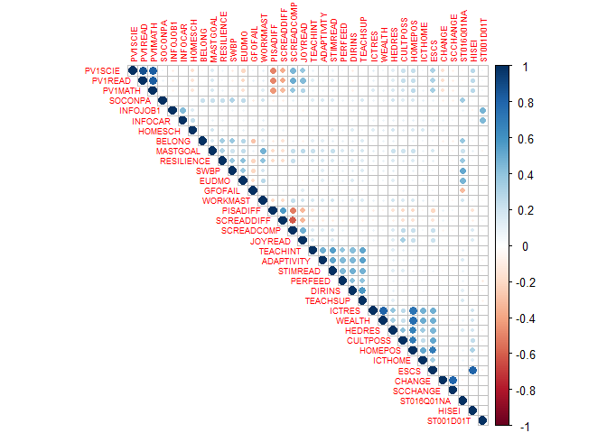

```r
correlation <- cor(IrlandaImput)

corrplot(correlation,
         type = "upper",
         tl.cex = 0.55,
         addshade = "positive") # show only upper part
```

```r
# Variância acumulada
variance <- apply(IrlandaImput, 2, var)

cumulative_variance <- cumsum(variance)

cumulative_variance
```

```
##    PV1SCIE    PV1READ    PV1MATH    SOCONPA   INFOJOB1    INFOCAR    HOMESCH
##   7687.927  15644.401  21602.145  21602.982  21603.962  21604.766  21605.575
##     BELONG   MASTGOAL RESILIENCE       SWBP      EUDMO    GFOFAIL   WORKMAST
##  21606.293  21607.202  21607.963  21608.782  21609.657  21610.614  21611.434
##   PISADIFF SCREADDIFF SCREADCOMP    JOYREAD   TEACHINT ADAPTIVITY   STIMREAD
##  21612.353  21613.314  21614.323  21615.510  21616.403  21617.257  21618.187
##    PERFEED     DIRINS   TEACHSUP     ICTRES     WEALTH     HEDRES   CULTPOSS
##  21619.115  21620.059  21621.031  21621.866  21622.514  21623.467  21624.801
##    HOMEPOS    ICTHOME       ESCS     CHANGE   SCCHANGE ST016Q01NA      HISEI
##  21625.560  21628.653  21629.388  21630.186  21630.532  21636.540  22116.795
##  ST001D01T
##  22117.236
```

## Teste de esfericidade de Bartlett em uma matriz de correlação.

O teste de esfericidade de Bartlett é um teste estatístico que avalia se as variáveis em um conjunto de dados estão correlacionadas entre si. Ele verifica a hipótese nula de que a matriz de correlação populacional é uma matriz de identidade, o que significa que as variáveis são independentes e não correlacionadas.

```r
cortest.bartlett(IrlandaImput)
```

```
## R was not square, finding R from data
```

```
## $chisq
## [1] 101644
##
## $p.value
## [1] 0
##
## $df
## [1] 630
```

Se o valor-p (p-value) calculado no teste de esfericidade de Bartlett for menor que 0.05, isso sugere evidências estatísticas para rejeitar a hipótese nula de que as variáveis são independentes e não correlacionadas, por outras palavras, existe uma correlação significativa entre as variáveis em questão. Isso significa que as variáveis não podem ser consideradas independentes, existindo algum grau de relação entre elas.

# Estandardizar os dados

```r
data_scaled <- scale(IrlandaImput)
data_scaled %>% glimpse()
```

```
##  num [1:5456, 1:36] -1.068 0.796 0.577 1.812 1.873 ...
##  - attr(*, "dimnames")=List of 2
##   ..$ : NULL
##   ..$ : chr [1:36] "PV1SCIE" "PV1READ" "PV1MATH" "SOCONPA" ...
##  - attr(*, "scaled:center")= Named num [1:36] 497.268 520.339 500.83 0.16 -0.104 ...
##   ..- attr(*, "names")= chr [1:36] "PV1SCIE" "PV1READ" "PV1MATH" "SOCONPA" ...
##  - attr(*, "scaled:scale")= Named num [1:36] 87.681 89.199 77.186 0.915 0.99 ...
##   ..- attr(*, "names")= chr [1:36] "PV1SCIE" "PV1READ" "PV1MATH" "SOCONPA" ...
```

```r
# Dúvida: Estandardizamos os dados de variáveis que não têm distribuição normal?
```

# PCA

Nesta parte, passaremos então para o processo de criação de PCA’s. Podemos então começar por pensar algumas ideias por alto, podendo ser estas:

- **PCA de Desempenho Acadêmico**:
  - Variáveis de interesse: Pontuações em diferentes domínios acadêmicos, como leitura, matemática e ciências.
  - Objetivo: Compreender a estrutura subjacente do desempenho acadêmico dos alunos e identificar padrões gerais de habilidades e competências.
- **PCA de Fatores Socioeconômicos**:
  - Variáveis de interesse: Variáveis socioeconômicas, como o nível de educação dos pais, ocupação dos pais, renda familiar, acesso a recursos educacionais, etc.
  - Objetivo: Explorar as relações entre os fatores socioeconômicos e o desempenho acadêmico dos alunos, bem como identificar grupos de alunos com perfis socioeconômicos semelhantes.
- **PCA de Atitudes e Comportamentos**:
  - Variáveis de interesse: Variáveis relacionadas a atitudes, motivação, autoeficácia, disciplina, participação em atividades extracurriculares, etc.
  - Objetivo: Identificar padrões de atitudes e comportamentos dos alunos que podem influenciar seu desempenho académico e bem-estar geral.
- **PCA de Ambiente Escolar**:
  - Variáveis de interesse: Variáveis relacionadas ao ambiente escolar, como tamanho da turma, recursos educacionais disponíveis, clima escolar, relacionamento professor-aluno, etc.
  - Objetivo: Explorar a relação entre o ambiente escolar e o desempenho dos alunos, bem como identificar características importantes do ambiente que afetam o aprendizado.

## Criação do PCA

```r
dim(data_scaled)
```

```
## [1] 5456   36
```

```r
pc1 <- principal(data_scaled, nfactors=20, rotate="none")
```

### Kaiser Criterion

```r
valores <- round(pc1$values,3)
valores
```

```
##  [1] 6.031 3.959 3.301 2.385 1.994 1.791 1.432 1.261 1.059 0.947 0.832 0.768
## [13] 0.723 0.710 0.645 0.627 0.617 0.597 0.571 0.534 0.521 0.504 0.495 0.477
## [25] 0.471 0.456 0.432 0.405 0.353 0.322 0.199 0.189 0.163 0.119 0.085 0.026
```

```r
length(valores[valores > 1])
```

```
## [1] 9
```

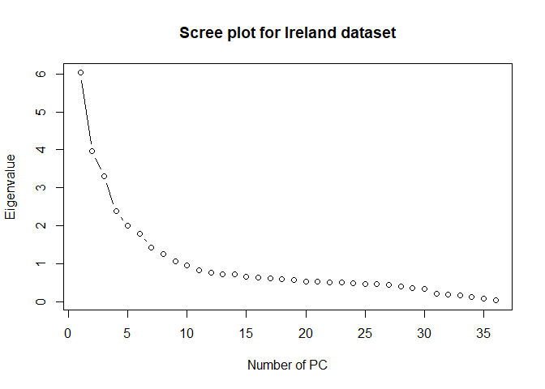

```r
plot(pc1$values, type = "b", main = "Scree plot for Ireland dataset",
     xlab = "Number of PC", ylab = "Eigenvalue")
```

Analisando o gráfico com atenção, é possível visualizar que existem várias quedas brutas, devido a isso, serão realizados vários testes com diferentes valores.

## PCA

Para uma melhor análise, é necessário ter conhecimento de algumas componentes e, para tal, de seguida teremos cada uma explicada de forma simples:

> SS loadings: Representa a soma dos quadrados das cargas dos componentes principais. Quanto maior o valor, mais bem os componentes capturam a variabilidade dos dados.

> Proportion Var: Indica a proporção da variância total explicada por cada componente principal. Quanto maior o valor, mais bem o componente explica a variabilidade dos dados em relação ao total.

> Cumulative Var: Representa a variância cumulativa explicada pelos componentes principais até o componente atual. É a soma acumulada das proporções de variância. Quanto maior o valor, mais bem os componentes principais explicam a variabilidade total dos dados à medida que adicionam-se mais componentes.

### Experiência com 6

```r
pc12 <- principal(data_scaled, nfactors = 6, rotate = "none")
pc12$loadings
```

```
##
## Loadings:
##            PC1    PC2    PC3    PC4    PC5    PC6
## PV1SCIE     0.551 -0.535 -0.393
## PV1READ     0.571 -0.520 -0.423
## PV1MATH     0.554 -0.483 -0.315 -0.123        -0.104
## SOCONPA     0.332  0.303        -0.279
## INFOJOB1           0.202  0.128         0.612 -0.416
## INFOCAR     0.121         0.160         0.707 -0.309
## HOMESCH     0.136  0.241  0.266  0.145  0.292
## BELONG      0.245  0.377        -0.443 -0.116
## MASTGOAL    0.477  0.222        -0.120  0.161  0.111
## RESILIENCE  0.397  0.378        -0.427  0.104  0.117
## SWBP        0.231  0.482  0.104 -0.441
## EUDMO       0.174  0.548  0.133 -0.380         0.118
## GFOFAIL           -0.244         0.393  0.146
## WORKMAST    0.430  0.241        -0.188  0.199  0.117
## PISADIFF   -0.519  0.261  0.366  0.146
## SCREADDIFF -0.461  0.173  0.383  0.181        -0.149
## SCREADCOMP  0.570 -0.215 -0.373 -0.105  0.154  0.139
## JOYREAD     0.463 -0.241 -0.284         0.205  0.146
## TEACHINT    0.392  0.415 -0.316  0.367
## ADAPTIVITY  0.376  0.468 -0.281  0.350
## STIMREAD    0.418  0.428 -0.298  0.398
## PERFEED     0.294  0.409 -0.230  0.358 -0.151
## DIRINS      0.262  0.554 -0.196  0.401
## TEACHSUP    0.342  0.512 -0.260  0.376 -0.136
## ICTRES      0.501 -0.118  0.600  0.125 -0.104
## WEALTH      0.460         0.645        -0.158
## HEDRES      0.560         0.376
## CULTPOSS    0.569 -0.139  0.235  0.131
## HOMEPOS     0.729 -0.155  0.571  0.137
## ICTHOME     0.388         0.495               -0.107
## ESCS        0.649 -0.296  0.408
## CHANGE     -0.135         0.162  0.203  0.400  0.748
## SCCHANGE   -0.120                0.182  0.396  0.755
## ST016Q01NA  0.271  0.482        -0.512
## HISEI       0.407 -0.294  0.197
## ST001D01T                               0.639 -0.440
##
##                  PC1   PC2   PC3   PC4   PC5   PC6
## SS loadings    6.031 3.959 3.301 2.385 1.994 1.791
## Proportion Var 0.168 0.110 0.092 0.066 0.055 0.050
## Cumulative Var 0.168 0.277 0.369 0.435 0.491 0.541
```

```r
round(pc12$communality,2)
```

```
##    PV1SCIE    PV1READ    PV1MATH    SOCONPA   INFOJOB1    INFOCAR    HOMESCH
##       0.76       0.79       0.67       0.28       0.60       0.64       0.25
##     BELONG   MASTGOAL RESILIENCE       SWBP      EUDMO    GFOFAIL   WORKMAST
##       0.41       0.34       0.51       0.49       0.51       0.24       0.34
##   PISADIFF SCREADDIFF SCREADCOMP    JOYREAD   TEACHINT ADAPTIVITY   STIMREAD
##       0.51       0.45       0.56       0.42       0.57       0.57       0.61
##    PERFEED     DIRINS   TEACHSUP     ICTRES     WEALTH     HEDRES   CULTPOSS
##       0.46       0.58       0.61       0.65       0.67       0.46       0.43
##    HOMEPOS    ICTHOME       ESCS     CHANGE   SCCHANGE ST016Q01NA      HISEI
##       0.91       0.42       0.69       0.81       0.78       0.57       0.30
##  ST001D01T
##       0.61
```

```r
# interessante
pc12r <- principal(data_scaled, nfactors= 6, rotate="varimax")
pc12r$loadings
```

```
##
## Loadings:
##            RC1    RC3    RC2    RC4    RC5    RC6
## PV1SCIE     0.833  0.123        -0.119        -0.183
## PV1READ     0.853  0.113        -0.114        -0.185
## PV1MATH     0.765  0.171                      -0.213
## SOCONPA            0.127  0.136  0.483
## INFOJOB1   -0.101                       0.766
## INFOCAR                                 0.792
## HOMESCH    -0.154  0.227  0.156         0.324  0.201
## BELONG                           0.628
## MASTGOAL    0.291  0.156  0.238  0.370  0.120  0.138
## RESILIENCE  0.178         0.102  0.668
## SWBP                             0.692
## EUDMO      -0.148         0.104  0.678         0.103
## GFOFAIL                         -0.444  0.119
## WORKMAST    0.273  0.105  0.187  0.416  0.147  0.151
## PISADIFF   -0.699
## SCREADDIFF -0.639               -0.162
## SCREADCOMP  0.723         0.121  0.112
## JOYREAD     0.601  0.101  0.129                0.160
## TEACHINT    0.141         0.734
## ADAPTIVITY                0.744  0.114
## STIMREAD    0.137         0.762
## PERFEED                   0.669
## DIRINS                    0.743  0.102
## TEACHSUP                  0.770  0.113
## ICTRES             0.806
## WEALTH             0.808
## HEDRES      0.109  0.635  0.139  0.153
## CULTPOSS    0.285  0.564  0.109                0.116
## HOMEPOS     0.172  0.932
## ICTHOME            0.629
## ESCS        0.299  0.772
## CHANGE     -0.101                              0.891
## SCCHANGE                                       0.877
## ST016Q01NA                       0.750
## HISEI       0.278  0.454
## ST001D01T                -0.106         0.759
##
##                  RC1   RC3   RC2   RC4   RC5   RC6
## SS loadings    4.424 4.310 3.549 3.277 2.006 1.894
## Proportion Var 0.123 0.120 0.099 0.091 0.056 0.053
## Cumulative Var 0.123 0.243 0.341 0.432 0.488 0.541
```

```r
round(pc12r$communality,2)
```

```
##    PV1SCIE    PV1READ    PV1MATH    SOCONPA   INFOJOB1    INFOCAR    HOMESCH
##       0.76       0.79       0.67       0.28       0.60       0.64       0.25
##     BELONG   MASTGOAL RESILIENCE       SWBP      EUDMO    GFOFAIL   WORKMAST
##       0.41       0.34       0.51       0.49       0.51       0.24       0.34
##   PISADIFF SCREADDIFF SCREADCOMP    JOYREAD   TEACHINT ADAPTIVITY   STIMREAD
##       0.51       0.45       0.56       0.42       0.57       0.57       0.61
##    PERFEED     DIRINS   TEACHSUP     ICTRES     WEALTH     HEDRES   CULTPOSS
##       0.46       0.58       0.61       0.65       0.67       0.46       0.43
##    HOMEPOS    ICTHOME       ESCS     CHANGE   SCCHANGE ST016Q01NA      HISEI
##       0.91       0.42       0.69       0.81       0.78       0.57       0.30
##  ST001D01T
##       0.61
```

### RC1 - Sucesso Académico (SA)

- Esta componente principal tem em conta os resultados da avaliação do estudante nos três campos de conhecimento (ciências, leitura e matemática) bem como a dificuldade percepcionada pelo mesmo e, também, a sua percepção quer sobre dificuldade do teste, quer sobre a sua competência.

### RC3 - Estatuto socio-económico (ESE)

- Esta componente principal tem em com conta as posses do estudante em casa bem como o seu estatuto económico, social e cultural. Esta componente principal também tem em atenção os recursos que o estudante tem quer em casa, quer no que diz respeito a ICT por si só.

### RC2 - Apoio por parte do professor (APP)

- Esta componente principal tem em conta a percepção do estudante quer no que diz respeito interesse do professor, quer no que diz respeito ao estímulo proveniente do mesmo para que os estudantes leiam. Esta componente principal também tem em conta a adaptabilidade do ensino do professor e apoio deste em aulas sobre línguas.

### RC4 - Alegria e bem-estar interior (ABEI)

- Esta componente principal tem em conta a satisfação do estudante com a sua vida e o significado da mesma para si próprio. Esta componente principal também tem em conta os sentimentos positivos do estudante, sendo estes sentimentos como pertença, conforto com o seu corpo e a sua aparência, ausência de receio de falhar, resiliência e bom relacionamento com os pais.

### RC6 - Mudança de escola (ME)

- Esta componente principal tem em conta o total de vezes que o estudante mudou de escola.

```r
pc12o <- principal(data_scaled, nfactors= 6, rotate="oblimin")
pc12o$loadings
```

```
##
## Loadings:
##            TC1    TC3    TC2    TC4    TC5    TC6
## PV1SCIE     0.840                             -0.118
## PV1READ     0.859                             -0.119
## PV1MATH     0.766                             -0.155
## SOCONPA                          0.471        -0.108
## INFOJOB1   -0.104                       0.763
## INFOCAR                                 0.790
## HOMESCH    -0.190  0.235  0.147         0.305  0.180
## BELONG                           0.636        -0.110
## MASTGOAL    0.266         0.185  0.354  0.102  0.140
## RESILIENCE  0.168                0.679
## SWBP                             0.695
## EUDMO      -0.163                0.678
## GFOFAIL                   0.138 -0.468  0.131  0.101
## WORKMAST    0.256         0.127  0.411  0.130  0.151
## PISADIFF   -0.705               -0.112
## SCREADDIFF -0.650               -0.185
## SCREADCOMP  0.724                0.126         0.134
## JOYREAD     0.597         0.117                0.201
## TEACHINT                  0.744
## ADAPTIVITY                0.751
## STIMREAD                  0.773
## PERFEED                   0.682
## DIRINS     -0.131         0.756
## TEACHSUP                  0.780
## ICTRES             0.825
## WEALTH     -0.175  0.834
## HEDRES             0.625  0.107  0.106
## CULTPOSS    0.227  0.540                       0.135
## HOMEPOS            0.928
## ICTHOME    -0.153  0.646
## ESCS        0.229  0.759
## CHANGE                                         0.887
## SCCHANGE                                       0.880
## ST016Q01NA                       0.757
## HISEI       0.244  0.439 -0.105
## ST001D01T                -0.105         0.770
##
##                  TC1   TC3   TC2   TC4   TC5   TC6
## SS loadings    4.370 4.229 3.542 3.230 1.987 1.878
## Proportion Var 0.121 0.117 0.098 0.090 0.055 0.052
## Cumulative Var 0.121 0.239 0.337 0.427 0.482 0.534
```

```r
round(pc12o$communality,2)
```

```
##    PV1SCIE    PV1READ    PV1MATH    SOCONPA   INFOJOB1    INFOCAR    HOMESCH
##       0.76       0.79       0.67       0.28       0.60       0.64       0.25
##     BELONG   MASTGOAL RESILIENCE       SWBP      EUDMO    GFOFAIL   WORKMAST
##       0.41       0.34       0.51       0.49       0.51       0.24       0.34
##   PISADIFF SCREADDIFF SCREADCOMP    JOYREAD   TEACHINT ADAPTIVITY   STIMREAD
##       0.51       0.45       0.56       0.42       0.57       0.57       0.61
##    PERFEED     DIRINS   TEACHSUP     ICTRES     WEALTH     HEDRES   CULTPOSS
##       0.46       0.58       0.61       0.65       0.67       0.46       0.43
##    HOMEPOS    ICTHOME       ESCS     CHANGE   SCCHANGE ST016Q01NA      HISEI
##       0.91       0.42       0.69       0.81       0.78       0.57       0.30
##  ST001D01T
##       0.61
```

```r
pc12pro <- principal(data_scaled, nfactors= 6, rotate="promax")
pc12pro$loadings
```

```
##
## Loadings:
##            RC1    RC3    RC2    RC4    RC5    RC6
## PV1SCIE     0.879               -0.135        -0.144
## PV1READ     0.898               -0.135        -0.146
## PV1MATH     0.805                             -0.179
## SOCONPA                          0.480        -0.115
## INFOJOB1                                0.775
## INFOCAR                                 0.794
## HOMESCH    -0.227  0.220  0.130         0.291  0.170
## BELONG                           0.655        -0.108
## MASTGOAL    0.221         0.156  0.338         0.126
## RESILIENCE  0.114                0.683
## SWBP       -0.131                0.717
## EUDMO      -0.223                0.698
## GFOFAIL                   0.146 -0.492  0.130
## WORKMAST    0.209                0.398  0.118  0.138
## PISADIFF   -0.706
## SCREADDIFF -0.638  0.119        -0.158
## SCREADCOMP  0.710                              0.113
## JOYREAD     0.582                              0.181
## TEACHINT                  0.758
## ADAPTIVITY                0.767
## STIMREAD                  0.786
## PERFEED                   0.702        -0.106
## DIRINS     -0.159         0.772
## TEACHSUP                  0.801
## ICTRES     -0.103  0.839
## WEALTH     -0.181  0.854                      -0.102
## HEDRES             0.624
## CULTPOSS    0.203  0.532                       0.119
## HOMEPOS            0.935
## ICTHOME    -0.159  0.658
## ESCS        0.218  0.763
## CHANGE     -0.207                              0.904
## SCCHANGE   -0.112                              0.897
## ST016Q01NA                       0.780
## HISEI       0.244  0.442 -0.119
## ST001D01T         -0.125 -0.125         0.789 -0.125
##
##                  RC1   RC3   RC2   RC4   RC5   RC6
## SS loadings    4.550 4.311 3.682 3.377 2.037 1.940
## Proportion Var 0.126 0.120 0.102 0.094 0.057 0.054
## Cumulative Var 0.126 0.246 0.348 0.442 0.499 0.553
```

```r
round(pc12pro$communality,2)
```

```
##    PV1SCIE    PV1READ    PV1MATH    SOCONPA   INFOJOB1    INFOCAR    HOMESCH
##       0.76       0.79       0.67       0.28       0.60       0.64       0.25
##     BELONG   MASTGOAL RESILIENCE       SWBP      EUDMO    GFOFAIL   WORKMAST
##       0.41       0.34       0.51       0.49       0.51       0.24       0.34
##   PISADIFF SCREADDIFF SCREADCOMP    JOYREAD   TEACHINT ADAPTIVITY   STIMREAD
##       0.51       0.45       0.56       0.42       0.57       0.57       0.61
##    PERFEED     DIRINS   TEACHSUP     ICTRES     WEALTH     HEDRES   CULTPOSS
##       0.46       0.58       0.61       0.65       0.67       0.46       0.43
##    HOMEPOS    ICTHOME       ESCS     CHANGE   SCCHANGE ST016Q01NA      HISEI
##       0.91       0.42       0.69       0.81       0.78       0.57       0.30
##  ST001D01T
##       0.61
```

```r
pc12qua <- principal(data_scaled, nfactors= 6, rotate="quartimin")
pc12qua$loadings
```

```
##
## Loadings:
##            TC1    TC3    TC2    TC4    TC5    TC6
## PV1SCIE     0.840                             -0.118
## PV1READ     0.859                             -0.119
## PV1MATH     0.766                             -0.155
## SOCONPA                          0.471        -0.108
## INFOJOB1   -0.104                       0.763
## INFOCAR                                 0.790
## HOMESCH    -0.190  0.235  0.147         0.305  0.180
## BELONG                           0.636        -0.110
## MASTGOAL    0.266         0.185  0.354  0.102  0.140
## RESILIENCE  0.168                0.679
## SWBP                             0.695
## EUDMO      -0.163                0.678
## GFOFAIL                   0.138 -0.468  0.131  0.101
## WORKMAST    0.256         0.127  0.411  0.130  0.151
## PISADIFF   -0.705               -0.112
## SCREADDIFF -0.650               -0.185
## SCREADCOMP  0.724                0.126         0.134
## JOYREAD     0.597         0.117                0.201
## TEACHINT                  0.744
## ADAPTIVITY                0.751
## STIMREAD                  0.773
## PERFEED                   0.682
## DIRINS     -0.131         0.756
## TEACHSUP                  0.780
## ICTRES             0.825
## WEALTH     -0.175  0.834
## HEDRES             0.625  0.107  0.106
## CULTPOSS    0.227  0.540                       0.135
## HOMEPOS            0.928
## ICTHOME    -0.153  0.646
## ESCS        0.229  0.759
## CHANGE                                         0.887
## SCCHANGE                                       0.880
## ST016Q01NA                       0.757
## HISEI       0.244  0.439 -0.105
## ST001D01T                -0.105         0.770
##
##                  TC1   TC3   TC2   TC4   TC5   TC6
## SS loadings    4.370 4.229 3.542 3.230 1.987 1.878
## Proportion Var 0.121 0.117 0.098 0.090 0.055 0.052
## Cumulative Var 0.121 0.239 0.337 0.427 0.482 0.534
```

```r
round(pc12qua$communality,2)
```

```
##    PV1SCIE    PV1READ    PV1MATH    SOCONPA   INFOJOB1    INFOCAR    HOMESCH
##       0.76       0.79       0.67       0.28       0.60       0.64       0.25
##     BELONG   MASTGOAL RESILIENCE       SWBP      EUDMO    GFOFAIL   WORKMAST
##       0.41       0.34       0.51       0.49       0.51       0.24       0.34
##   PISADIFF SCREADDIFF SCREADCOMP    JOYREAD   TEACHINT ADAPTIVITY   STIMREAD
##       0.51       0.45       0.56       0.42       0.57       0.57       0.61
##    PERFEED     DIRINS   TEACHSUP     ICTRES     WEALTH     HEDRES   CULTPOSS
##       0.46       0.58       0.61       0.65       0.67       0.46       0.43
##    HOMEPOS    ICTHOME       ESCS     CHANGE   SCCHANGE ST016Q01NA      HISEI
##       0.91       0.42       0.69       0.81       0.78       0.57       0.30
##  ST001D01T
##       0.61
```

```r
pc12equ <- principal(data_scaled, nfactors= 6, rotate="equamax")
pc12equ$loadings
```

```
##
## Loadings:
##            RC1    RC3    RC2    RC4    RC5    RC6
## PV1SCIE     0.844  0.117                      -0.150
## PV1READ     0.863  0.107                      -0.152
## PV1MATH     0.775  0.166                      -0.185
## SOCONPA            0.129  0.143  0.479        -0.117
## INFOJOB1   -0.112                       0.764
## INFOCAR                                 0.792
## HOMESCH    -0.170  0.228  0.159         0.320  0.190
## BELONG                           0.622        -0.121
## MASTGOAL    0.267  0.157  0.252  0.382  0.117  0.127
## RESILIENCE  0.149         0.116  0.676
## SWBP                             0.686
## EUDMO      -0.178         0.110  0.675
## GFOFAIL                         -0.437  0.123  0.105
## WORKMAST    0.247  0.106  0.201  0.430  0.145  0.138
## PISADIFF   -0.695               -0.117
## SCREADDIFF -0.630               -0.185
## SCREADCOMP  0.713         0.141  0.140         0.105
## JOYREAD     0.593         0.145                0.179
## TEACHINT    0.121         0.738
## ADAPTIVITY                0.746  0.105
## STIMREAD    0.116         0.766
## PERFEED                   0.669
## DIRINS                    0.744
## TEACHSUP                  0.770  0.101
## ICTRES             0.807
## WEALTH             0.808
## HEDRES      0.102  0.635  0.146  0.152
## CULTPOSS    0.280  0.563  0.119                0.121
## HOMEPOS     0.172  0.931
## ICTHOME            0.630
## ESCS        0.303  0.771
## CHANGE     -0.129                              0.889
## SCCHANGE                                       0.880
## ST016Q01NA                       0.744        -0.107
## HISEI       0.284  0.452
## ST001D01T                               0.761
##
##                  RC1   RC3   RC2   RC4   RC5   RC6
## SS loadings    4.415 4.303 3.604 3.258 1.999 1.882
## Proportion Var 0.123 0.120 0.100 0.090 0.056 0.052
## Cumulative Var 0.123 0.242 0.342 0.433 0.488 0.541
```

```r
round(pc12equ$communality,2)
```

```
##    PV1SCIE    PV1READ    PV1MATH    SOCONPA   INFOJOB1    INFOCAR    HOMESCH
##       0.76       0.79       0.67       0.28       0.60       0.64       0.25
##     BELONG   MASTGOAL RESILIENCE       SWBP      EUDMO    GFOFAIL   WORKMAST
##       0.41       0.34       0.51       0.49       0.51       0.24       0.34
##   PISADIFF SCREADDIFF SCREADCOMP    JOYREAD   TEACHINT ADAPTIVITY   STIMREAD
##       0.51       0.45       0.56       0.42       0.57       0.57       0.61
##    PERFEED     DIRINS   TEACHSUP     ICTRES     WEALTH     HEDRES   CULTPOSS
##       0.46       0.58       0.61       0.65       0.67       0.46       0.43
##    HOMEPOS    ICTHOME       ESCS     CHANGE   SCCHANGE ST016Q01NA      HISEI
##       0.91       0.42       0.69       0.81       0.78       0.57       0.30
##  ST001D01T
##       0.61
```

### Experiência com 7

```r
pc7 <- principal(data_scaled, nfactors = 7, rotate = "none")
pc7$loadings
```

```
##
## Loadings:
##            PC1    PC2    PC3    PC4    PC5    PC6    PC7
## PV1SCIE     0.551 -0.535 -0.393                       0.193
## PV1READ     0.571 -0.520 -0.423                       0.127
## PV1MATH     0.554 -0.483 -0.315 -0.123        -0.104  0.208
## SOCONPA     0.332  0.303        -0.279
## INFOJOB1           0.202  0.128         0.612 -0.416  0.185
## INFOCAR     0.121         0.160         0.707 -0.309
## HOMESCH     0.136  0.241  0.266  0.145  0.292        -0.319
## BELONG      0.245  0.377        -0.443 -0.116         0.203
## MASTGOAL    0.477  0.222        -0.120  0.161  0.111 -0.441
## RESILIENCE  0.397  0.378        -0.427  0.104  0.117
## SWBP        0.231  0.482  0.104 -0.441
## EUDMO       0.174  0.548  0.133 -0.380         0.118 -0.111
## GFOFAIL           -0.244         0.393  0.146        -0.490
## WORKMAST    0.430  0.241        -0.188  0.199  0.117 -0.420
## PISADIFF   -0.519  0.261  0.366  0.146
## SCREADDIFF -0.461  0.173  0.383  0.181        -0.149
## SCREADCOMP  0.570 -0.215 -0.373 -0.105  0.154  0.139
## JOYREAD     0.463 -0.241 -0.284         0.205  0.146 -0.279
## TEACHINT    0.392  0.415 -0.316  0.367
## ADAPTIVITY  0.376  0.468 -0.281  0.350                0.147
## STIMREAD    0.418  0.428 -0.298  0.398
## PERFEED     0.294  0.409 -0.230  0.358 -0.151
## DIRINS      0.262  0.554 -0.196  0.401
## TEACHSUP    0.342  0.512 -0.260  0.376 -0.136         0.155
## ICTRES      0.501 -0.118  0.600  0.125 -0.104         0.129
## WEALTH      0.460         0.645        -0.158         0.138
## HEDRES      0.560         0.376                      -0.101
## CULTPOSS    0.569 -0.139  0.235  0.131               -0.188
## HOMEPOS     0.729 -0.155  0.571  0.137
## ICTHOME     0.388         0.495               -0.107
## ESCS        0.649 -0.296  0.408
## CHANGE     -0.135         0.162  0.203  0.400  0.748  0.267
## SCCHANGE   -0.120                0.182  0.396  0.755  0.306
## ST016Q01NA  0.271  0.482        -0.512                0.166
## HISEI       0.407 -0.294  0.197                       0.134
## ST001D01T                               0.639 -0.440  0.258
##
##                  PC1   PC2   PC3   PC4   PC5   PC6   PC7
## SS loadings    6.031 3.959 3.301 2.385 1.994 1.791 1.432
## Proportion Var 0.168 0.110 0.092 0.066 0.055 0.050 0.040
## Cumulative Var 0.168 0.277 0.369 0.435 0.491 0.541 0.580
```

```r
round(pc7$communality,2)
```

```
##    PV1SCIE    PV1READ    PV1MATH    SOCONPA   INFOJOB1    INFOCAR    HOMESCH
##       0.80       0.80       0.71       0.29       0.64       0.65       0.35
##     BELONG   MASTGOAL RESILIENCE       SWBP      EUDMO    GFOFAIL   WORKMAST
##       0.45       0.53       0.51       0.50       0.52       0.48       0.51
##   PISADIFF SCREADDIFF SCREADCOMP    JOYREAD   TEACHINT ADAPTIVITY   STIMREAD
##       0.51       0.45       0.57       0.50       0.57       0.60       0.61
##    PERFEED     DIRINS   TEACHSUP     ICTRES     WEALTH     HEDRES   CULTPOSS
##       0.47       0.58       0.63       0.67       0.69       0.47       0.46
##    HOMEPOS    ICTHOME       ESCS     CHANGE   SCCHANGE ST016Q01NA      HISEI
##       0.91       0.43       0.70       0.88       0.87       0.60       0.32
##  ST001D01T
##       0.67
```

```r
pc7r <- principal(data_scaled, nfactors= 7, rotate="varimax")
pc7r$loadings
```

```
##
## Loadings:
##            RC1    RC3    RC2    RC4    RC5    RC7    RC6
## PV1SCIE     0.863  0.142                      -0.105 -0.103
## PV1READ     0.872  0.124                             -0.127
## PV1MATH     0.799  0.191                      -0.124 -0.129
## SOCONPA            0.118  0.125  0.467         0.138 -0.120
## INFOJOB1   -0.103                       0.786
## INFOCAR                                 0.769  0.205
## HOMESCH    -0.234  0.186                0.216  0.454
## BELONG                           0.655
## MASTGOAL    0.193         0.154  0.268         0.621
## RESILIENCE  0.147                0.638         0.261
## SWBP                             0.692
## EUDMO      -0.184                0.642         0.256
## GFOFAIL                         -0.531         0.435
## WORKMAST    0.178         0.106  0.318         0.606
## PISADIFF   -0.695
## SCREADDIFF -0.634               -0.155        -0.101
## SCREADCOMP  0.689         0.103                0.271
## JOYREAD     0.534               -0.120         0.430
## TEACHINT    0.125         0.732                0.111
## ADAPTIVITY                0.757  0.122
## STIMREAD    0.116         0.755                0.142
## PERFEED                   0.675
## DIRINS                    0.744
## TEACHSUP                  0.785  0.124
## ICTRES             0.815
## WEALTH             0.819
## HEDRES             0.617  0.114  0.120         0.243
## CULTPOSS    0.234  0.536                       0.335
## HOMEPOS     0.154  0.922                       0.165
## ICTHOME            0.633
## ESCS        0.300  0.775
## CHANGE     -0.110                                     0.930
## SCCHANGE                                              0.933
## ST016Q01NA                       0.767
## HISEI       0.296  0.465
## ST001D01T                               0.807
##
##                  RC1   RC3   RC2   RC4   RC5   RC7   RC6
## SS loadings    4.326 4.241 3.464 3.157 1.941 1.923 1.841
## Proportion Var 0.120 0.118 0.096 0.088 0.054 0.053 0.051
## Cumulative Var 0.120 0.238 0.334 0.422 0.476 0.529 0.580
```

```r
round(pc7r$communality,2)
```

```
##    PV1SCIE    PV1READ    PV1MATH    SOCONPA   INFOJOB1    INFOCAR    HOMESCH
##       0.80       0.80       0.71       0.29       0.64       0.65       0.35
##     BELONG   MASTGOAL RESILIENCE       SWBP      EUDMO    GFOFAIL   WORKMAST
##       0.45       0.53       0.51       0.50       0.52       0.48       0.51
##   PISADIFF SCREADDIFF SCREADCOMP    JOYREAD   TEACHINT ADAPTIVITY   STIMREAD
##       0.51       0.45       0.57       0.50       0.57       0.60       0.61
##    PERFEED     DIRINS   TEACHSUP     ICTRES     WEALTH     HEDRES   CULTPOSS
##       0.47       0.58       0.63       0.67       0.69       0.47       0.46
##    HOMEPOS    ICTHOME       ESCS     CHANGE   SCCHANGE ST016Q01NA      HISEI
##       0.91       0.43       0.70       0.88       0.87       0.60       0.32
##  ST001D01T
##       0.67
```

```r
pc7o <- principal(data_scaled, nfactors= 7, rotate="oblimin")
pc7o$loadings
```

```
##
## Loadings:
##            TC3    TC1    TC2    TC4    TC5    TC7    TC6
## PV1SCIE            0.881
## PV1READ            0.876
## PV1MATH     0.107  0.815                      -0.106
## SOCONPA                          0.434         0.135 -0.125
## INFOJOB1                                0.787
## INFOCAR                                 0.769  0.171
## HOMESCH     0.198 -0.321                0.210  0.424
## BELONG                           0.665
## MASTGOAL                         0.181         0.634
## RESILIENCE         0.104         0.611         0.274
## SWBP                             0.677
## EUDMO             -0.230         0.604         0.260
## GFOFAIL                         -0.596         0.437
## WORKMAST                         0.241         0.625
## PISADIFF          -0.682                      -0.121
## SCREADDIFF        -0.623        -0.168        -0.130
## SCREADCOMP         0.645                       0.297
## JOYREAD            0.458        -0.159         0.453
## TEACHINT                  0.739
## ADAPTIVITY                0.769
## STIMREAD                  0.762
## PERFEED                   0.690
## DIRINS            -0.126  0.759
## TEACHSUP                  0.801
## ICTRES      0.831
## WEALTH      0.844 -0.118                      -0.139
## HEDRES      0.609                              0.197
## CULTPOSS    0.512  0.138                       0.308
## HOMEPOS     0.918                              0.102
## ICTHOME     0.649 -0.127
## ESCS        0.758  0.243
## CHANGE                                                0.929
## SCCHANGE                                              0.938
## ST016Q01NA                       0.765
## HISEI       0.447  0.281
## ST001D01T          0.126                0.812 -0.119
##
##                  TC3   TC1   TC2   TC4   TC5   TC7   TC6
## SS loadings    4.165 4.134 3.468 2.964 1.945 1.927 1.834
## Proportion Var 0.116 0.115 0.096 0.082 0.054 0.054 0.051
## Cumulative Var 0.116 0.231 0.327 0.409 0.463 0.517 0.568
```

```r
round(pc7o$communality,2)
```

```
##    PV1SCIE    PV1READ    PV1MATH    SOCONPA   INFOJOB1    INFOCAR    HOMESCH
##       0.80       0.80       0.71       0.29       0.64       0.65       0.35
##     BELONG   MASTGOAL RESILIENCE       SWBP      EUDMO    GFOFAIL   WORKMAST
##       0.45       0.53       0.51       0.50       0.52       0.48       0.51
##   PISADIFF SCREADDIFF SCREADCOMP    JOYREAD   TEACHINT ADAPTIVITY   STIMREAD
##       0.51       0.45       0.57       0.50       0.57       0.60       0.61
##    PERFEED     DIRINS   TEACHSUP     ICTRES     WEALTH     HEDRES   CULTPOSS
##       0.47       0.58       0.63       0.67       0.69       0.47       0.46
##    HOMEPOS    ICTHOME       ESCS     CHANGE   SCCHANGE ST016Q01NA      HISEI
##       0.91       0.43       0.70       0.88       0.87       0.60       0.32
##  ST001D01T
##       0.67
```

```r
pc7pro <- principal(data_scaled, nfactors= 7, rotate="promax")
pc7pro$loadings
```

```
##
## Loadings:
##            RC1    RC3    RC2    RC4    RC7    RC5    RC6
## PV1SCIE     0.906                      -0.115
## PV1READ     0.896
## PV1MATH     0.843  0.112               -0.137
## SOCONPA                          0.434  0.151        -0.117
## INFOJOB1                                       0.792
## INFOCAR                                 0.178  0.765
## HOMESCH    -0.354  0.153                0.463  0.180
## BELONG                           0.669
## MASTGOAL                         0.169  0.682
## RESILIENCE                       0.609  0.291
## SWBP       -0.105                0.683
## EUDMO      -0.269                0.609  0.288
## GFOFAIL    -0.113               -0.607  0.475        -0.110
## WORKMAST                         0.230  0.672
## PISADIFF   -0.675                      -0.107
## SCREADDIFF -0.607  0.110        -0.153 -0.118
## SCREADCOMP  0.618                       0.296
## JOYREAD     0.419               -0.178  0.469
## TEACHINT                  0.733
## ADAPTIVITY                0.771
## STIMREAD                  0.754
## PERFEED                   0.693
## DIRINS     -0.126         0.757
## TEACHSUP                  0.806
## ICTRES             0.843               -0.105
## WEALTH     -0.104  0.860               -0.149
## HEDRES             0.588                0.211
## CULTPOSS    0.108  0.481        -0.101  0.322
## HOMEPOS            0.909                0.103
## ICTHOME    -0.118  0.654
## ESCS        0.239  0.758
## CHANGE     -0.129                                     0.928
## SCCHANGE                                              0.937
## ST016Q01NA                       0.772
## HISEI       0.285  0.455               -0.101
## ST001D01T   0.188                      -0.134  0.828
##
##                  RC1   RC3   RC2   RC4   RC7   RC5   RC6
## SS loadings    4.212 4.151 3.436 3.005 2.216 1.968 1.830
## Proportion Var 0.117 0.115 0.095 0.083 0.062 0.055 0.051
## Cumulative Var 0.117 0.232 0.328 0.411 0.473 0.527 0.578
```

```r
round(pc7pro$communality,2)
```

```
##    PV1SCIE    PV1READ    PV1MATH    SOCONPA   INFOJOB1    INFOCAR    HOMESCH
##       0.80       0.80       0.71       0.29       0.64       0.65       0.35
##     BELONG   MASTGOAL RESILIENCE       SWBP      EUDMO    GFOFAIL   WORKMAST
##       0.45       0.53       0.51       0.50       0.52       0.48       0.51
##   PISADIFF SCREADDIFF SCREADCOMP    JOYREAD   TEACHINT ADAPTIVITY   STIMREAD
##       0.51       0.45       0.57       0.50       0.57       0.60       0.61
##    PERFEED     DIRINS   TEACHSUP     ICTRES     WEALTH     HEDRES   CULTPOSS
##       0.47       0.58       0.63       0.67       0.69       0.47       0.46
##    HOMEPOS    ICTHOME       ESCS     CHANGE   SCCHANGE ST016Q01NA      HISEI
##       0.91       0.43       0.70       0.88       0.87       0.60       0.32
##  ST001D01T
##       0.67
```

```r
pc7qua <- principal(data_scaled, nfactors= 7, rotate="quartimin")
pc7qua$loadings
```

```
##
## Loadings:
##            TC3    TC1    TC2    TC4    TC5    TC7    TC6
## PV1SCIE            0.881
## PV1READ            0.876
## PV1MATH     0.107  0.815                      -0.106
## SOCONPA                          0.434         0.135 -0.125
## INFOJOB1                                0.787
## INFOCAR                                 0.769  0.171
## HOMESCH     0.198 -0.321                0.210  0.424
## BELONG                           0.665
## MASTGOAL                         0.181         0.634
## RESILIENCE         0.104         0.611         0.274
## SWBP                             0.677
## EUDMO             -0.230         0.604         0.260
## GFOFAIL                         -0.596         0.437
## WORKMAST                         0.241         0.625
## PISADIFF          -0.682                      -0.121
## SCREADDIFF        -0.623        -0.168        -0.130
## SCREADCOMP         0.645                       0.297
## JOYREAD            0.458        -0.159         0.453
## TEACHINT                  0.739
## ADAPTIVITY                0.769
## STIMREAD                  0.762
## PERFEED                   0.690
## DIRINS            -0.126  0.759
## TEACHSUP                  0.801
## ICTRES      0.831
## WEALTH      0.844 -0.118                      -0.139
## HEDRES      0.609                              0.197
## CULTPOSS    0.512  0.138                       0.308
## HOMEPOS     0.918                              0.102
## ICTHOME     0.649 -0.127
## ESCS        0.758  0.243
## CHANGE                                                0.929
## SCCHANGE                                              0.938
## ST016Q01NA                       0.765
## HISEI       0.447  0.281
## ST001D01T          0.126                0.812 -0.119
##
##                  TC3   TC1   TC2   TC4   TC5   TC7   TC6
## SS loadings    4.165 4.134 3.468 2.964 1.945 1.927 1.834
## Proportion Var 0.116 0.115 0.096 0.082 0.054 0.054 0.051
## Cumulative Var 0.116 0.231 0.327 0.409 0.463 0.517 0.568
```

```r
round(pc7qua$communality,2)
```

```
##    PV1SCIE    PV1READ    PV1MATH    SOCONPA   INFOJOB1    INFOCAR    HOMESCH
##       0.80       0.80       0.71       0.29       0.64       0.65       0.35
##     BELONG   MASTGOAL RESILIENCE       SWBP      EUDMO    GFOFAIL   WORKMAST
##       0.45       0.53       0.51       0.50       0.52       0.48       0.51
##   PISADIFF SCREADDIFF SCREADCOMP    JOYREAD   TEACHINT ADAPTIVITY   STIMREAD
##       0.51       0.45       0.57       0.50       0.57       0.60       0.61
##    PERFEED     DIRINS   TEACHSUP     ICTRES     WEALTH     HEDRES   CULTPOSS
##       0.47       0.58       0.63       0.67       0.69       0.47       0.46
##    HOMEPOS    ICTHOME       ESCS     CHANGE   SCCHANGE ST016Q01NA      HISEI
##       0.91       0.43       0.70       0.88       0.87       0.60       0.32
##  ST001D01T
##       0.67
```

```r
pc7equ <- principal(data_scaled, nfactors= 7, rotate="equamax")
pc7equ$loadings
```

```
##
## Loadings:
##            RC3    RC1    RC2    RC4    RC7    RC5    RC6
## PV1SCIE     0.120  0.876
## PV1READ     0.102  0.875                             -0.123
## PV1MATH     0.171  0.814                             -0.126
## SOCONPA     0.117         0.128  0.442  0.200        -0.137
## INFOJOB1                                       0.788
## INFOCAR                                 0.182  0.774
## HOMESCH     0.189 -0.286                0.411  0.235
## BELONG                    0.101  0.660
## MASTGOAL                  0.148  0.191  0.672
## RESILIENCE                       0.604  0.352
## SWBP              -0.103         0.676  0.137
## EUDMO             -0.239         0.604  0.301
## GFOFAIL                         -0.582  0.365
## WORKMAST                  0.101  0.244  0.659
## PISADIFF          -0.672               -0.205
## SCREADDIFF        -0.605        -0.153 -0.211
## SCREADCOMP         0.641  0.103         0.376
## JOYREAD            0.472        -0.161  0.488
## TEACHINT           0.103  0.731         0.143
## ADAPTIVITY                0.758  0.111
## STIMREAD                  0.754         0.171
## PERFEED                   0.675
## DIRINS            -0.104  0.744
## TEACHSUP                  0.786  0.115
## ICTRES      0.815
## WEALTH      0.821
## HEDRES      0.614         0.114         0.268
## CULTPOSS    0.529  0.198                0.364
## HOMEPOS     0.918  0.149                0.196
## ICTHOME     0.634
## ESCS        0.767  0.308
## CHANGE            -0.113                              0.931
## SCCHANGE                                              0.934
## ST016Q01NA                       0.760
## HISEI       0.458  0.312
## ST001D01T                              -0.111  0.803
##
##                  RC3   RC1   RC2   RC4   RC7   RC5   RC6
## SS loadings    4.185 4.153 3.466 2.975 2.302 1.959 1.851
## Proportion Var 0.116 0.115 0.096 0.083 0.064 0.054 0.051
## Cumulative Var 0.116 0.232 0.328 0.411 0.474 0.529 0.580
```

```r
round(pc12equ$communality,2)
```

```
##    PV1SCIE    PV1READ    PV1MATH    SOCONPA   INFOJOB1    INFOCAR    HOMESCH
##       0.76       0.79       0.67       0.28       0.60       0.64       0.25
##     BELONG   MASTGOAL RESILIENCE       SWBP      EUDMO    GFOFAIL   WORKMAST
##       0.41       0.34       0.51       0.49       0.51       0.24       0.34
##   PISADIFF SCREADDIFF SCREADCOMP    JOYREAD   TEACHINT ADAPTIVITY   STIMREAD
##       0.51       0.45       0.56       0.42       0.57       0.57       0.61
##    PERFEED     DIRINS   TEACHSUP     ICTRES     WEALTH     HEDRES   CULTPOSS
##       0.46       0.58       0.61       0.65       0.67       0.46       0.43
##    HOMEPOS    ICTHOME       ESCS     CHANGE   SCCHANGE ST016Q01NA      HISEI
##       0.91       0.42       0.69       0.81       0.78       0.57       0.30
##  ST001D01T
##       0.61
```

```r
pc6sc <- principal(data_scaled, nfactors = 6, rotate = "varimax", scores = TRUE)
round(pc6sc$scores,3)
```

```
##            RC1    RC3    RC2    RC4    RC5    RC6
##    [1,] -0.754  1.321  1.336  0.139  0.130  2.429
##    [2,]  1.182  0.846  0.064 -0.766  1.997 -0.415
##    [3,]  1.166  0.260  1.579 -0.135  1.505 -0.148
##    [4,]  1.038  0.206 -0.256  0.206  1.172 -1.399
##    [5,]  0.342  2.053 -0.282 -0.398 -1.612 -1.528
##    [6,] -1.038  1.983 -0.184 -1.321  0.433 -1.301
##    [7,] -0.515  2.247  0.341 -1.439 -1.385 -0.712
##    [8,]  0.288 -0.221 -0.730  0.421 -1.226  1.820
##    [9,] -0.438  1.315 -0.106 -1.214 -1.087 -0.571
##   [10,]  1.163  0.461 -0.285 -0.117 -0.619  0.900
##   [11,]  0.695 -0.160  0.758 -0.197 -0.055  2.581
##   [12,] -1.413  1.366  0.882 -0.105 -0.583  0.272
##   [13,] -1.665  1.272 -0.037  0.635  1.552 -0.488
##   [14,] -0.459  2.264 -0.511  0.438 -0.976 -0.557
```

[output cut: 5442 more lines]

```r
mean(pc6sc$scores[,1])
```

```
## [1] -0.00000000000000001953482
```

```r
sd(pc6sc$scores[,1])
```

```
## [1] 1
```

```r
IrlandaImput$SA <- pc6sc$scores[,1] # RC1 - Sucesso Académico
IrlandaImput$ESE <- pc6sc$scores[,2] # RC3 - Estatuto socio-económico
IrlandaImput$APP <- pc6sc$scores[,3] # RC2 - Apoio por parte do professor
IrlandaImput$ABEI <- pc6sc$scores[,4] # RC4 - Alegria e bem-estar interior
IrlandaImput$NEIC <- pc6sc$scores[,5] # RC5 - Nível de educação e informação sobre carreiras
IrlandaImput$ME <- pc6sc$scores[,6] # RC6 - Mudança de escola
```

```r
dim(IrlandaImput)
```

```
## [1] 5456   42
```

```r
IrlandaImput[, 37:42]
```

```
## # A tibble: 5,456 × 6
##        SA    ESE     APP   ABEI   NEIC     ME
##     <dbl>  <dbl>   <dbl>  <dbl>  <dbl>  <dbl>
##  1 -0.754  1.32   1.34    0.139  0.130  2.43
##  2  1.18   0.846  0.0642 -0.766  2.00  -0.415
##  3  1.17   0.260  1.58   -0.135  1.50  -0.148
##  4  1.04   0.206 -0.256   0.206  1.17  -1.40
##  5  0.342  2.05  -0.282  -0.398 -1.61  -1.53
##  6 -1.04   1.98  -0.184  -1.32   0.433 -1.30
##  7 -0.515  2.25   0.341  -1.44  -1.39  -0.712
##  8  0.288 -0.221 -0.730   0.421 -1.23   1.82
##  9 -0.438  1.32  -0.106  -1.21  -1.09  -0.571
## 10  1.16   0.461 -0.285  -0.117 -0.619  0.900
## # ℹ 5,446 more rows
```

```r
IrlandaFinal<- IrlandaImputInc %>% select("ST004D01T", "AGE", "IMMIG", "HISCED", "FISCED", "MISCED", "ISCEDL")
IrlandaFinal <- IrlandaFinal %>%
  bind_cols(IrlandaImput[, 37:42])
```

```r
IrlandaFinal
```

```
## # A tibble: 5,456 × 13
##    ST004D01T   AGE IMMIG HISCED FISCED MISCED ISCEDL     SA    ESE     APP
##        <int> <dbl> <dbl>  <dbl>  <dbl>  <dbl>  <int>  <dbl>  <dbl>   <dbl>
##  1         2  15.3  1.61      6      6      4      2 -0.754  1.32   1.34
##  2         1  16    1         6      6      6      3  1.18   0.846  0.0642
##  3         1  15.9  1         6      6      6      3  1.17   0.260  1.58
##  4         2  16.1  1         6      6      5      3  1.04   0.206 -0.256
##  5         2  15.8  1         5      5      4      2  0.342  2.05  -0.282
##  6         2  15.8  1         6      6      6      3 -1.04   1.98  -0.184
##  7         2  15.3  1         6      6      6      2 -0.515  2.25   0.341
##  8         2  15.2  2         6      6      6      2  0.288 -0.221 -0.730
##  9         2  15.3  1         6      5      6      2 -0.438  1.32  -0.106
## 10         2  15.2  2         5      5      4      2  1.16   0.461 -0.285
## # ℹ 5,446 more rows
## # ℹ 3 more variables: ABEI <dbl>, NEIC <dbl>, ME <dbl>
```

```r
IrlandaFinal[8:12]
```

```
## # A tibble: 5,456 × 5
##        SA    ESE     APP   ABEI   NEIC
##     <dbl>  <dbl>   <dbl>  <dbl>  <dbl>
##  1 -0.754  1.32   1.34    0.139  0.130
##  2  1.18   0.846  0.0642 -0.766  2.00
##  3  1.17   0.260  1.58   -0.135  1.50
##  4  1.04   0.206 -0.256   0.206  1.17
##  5  0.342  2.05  -0.282  -0.398 -1.61
##  6 -1.04   1.98  -0.184  -1.32   0.433
##  7 -0.515  2.25   0.341  -1.44  -1.39
##  8  0.288 -0.221 -0.730   0.421 -1.23
##  9 -0.438  1.32  -0.106  -1.21  -1.09
## 10  1.16   0.461 -0.285  -0.117 -0.619
## # ℹ 5,446 more rows
```

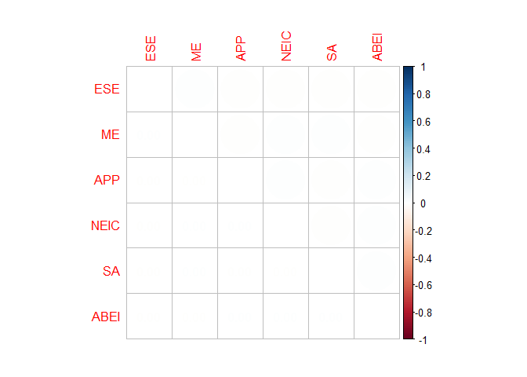

```r
corr <- cor(IrlandaImput[, 37:42])
par(oma = c(2, 2, 2, 2))   # space rounf the graph
corrplot.mixed(corr,
        order = "hclust",
        tl.pos = "lt",
        upper = "ellipse")
```

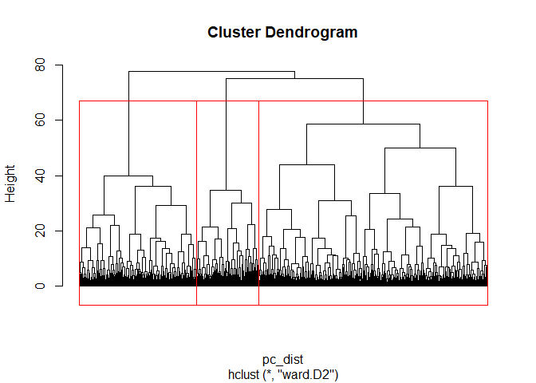

```r
pc_dist <- dist(IrlandaImput[, 37:42])
hclust  <- hclust(pc_dist, method='ward.D2')
plot(hclust, hang=-1, labels=FALSE)

groups.k5 <- cutree(hclust, k = 3)
rect.hclust(hclust, k = 3, border="red")
```

[figure not shown]

```r
# 4 ou 5 clusters?
plot(silhouette(groups.k5, pc_dist))
```

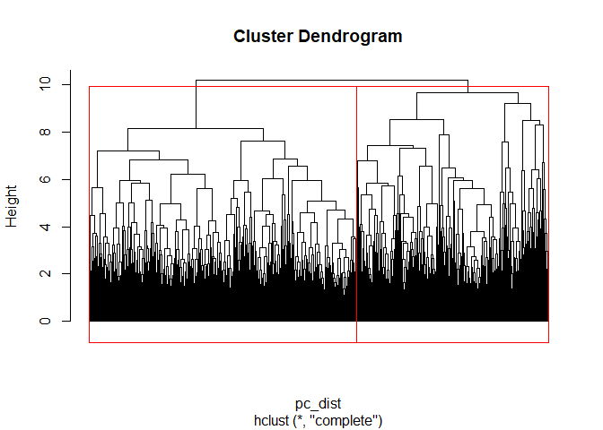

```r
pc_dist <- dist(IrlandaImput[, 37:42])
hclust  <- hclust(pc_dist, method='complete')
plot(hclust, hang=-1, labels=FALSE)

groups.k5_c <- cutree(hclust, k=2)
rect.hclust(hclust, k=2, border="red")
```

[figure not shown]

```r
plot(silhouette(groups.k5_c, pc_dist))
```

```r
table(groups.k5,groups.k5_c)
```

```
##          groups.k5_c
## groups.k5    1    2
##         1  536  296
##         2  449 1119
##         3 1288 1768
```

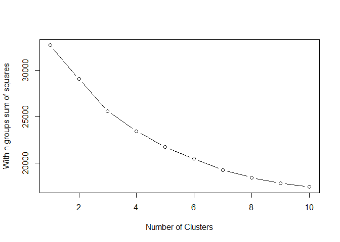

```r
# K-Means: number of clusters
wssplot <- function(xx, nc=15, seed=1234){
  wss <- (nrow(xx)-1)*sum(apply(xx,2,var))
  for (i in 2:nc){
    set.seed(seed)
    wss[i] <- sum(kmeans(xx, centers=i)$withinss)}
  plot(1:nc, wss, type="b", xlab="Number of Clusters",
       ylab="Within groups sum of squares")}
wssplot(IrlandaImput[, 37:42], nc=10)
```

```r
#K-means cluster com K=2
kmeans.k6 <- kmeans(IrlandaImput[, 37:42], 3, nstart=100)
IrlandaImput = IrlandaImput %>% mutate(cluster = kmeans.k6$cluster)
```